# IPW Test

Brian Richardson

12/03/2024

```r
rm(list = ls())
library(dplyr)
library(ggplot2)
library(MASS)
library(tmvtnorm)
library(devtools)
library(truncnorm)
load_all()
```

The goal of this program is to explore some strange results of the IPW estimator with continuous treatments.

### Scenario 1

Consider the following scenario:

- confounder $L \sim N(0, 1)$,
- exposure $A$ with $A|L \sim N(0.5L, 1)$,
- outcome $Y$ with $Y|A,L \sim N(A-L,1)$.

This results in an MSM of $\textrm{E}\{Y(a)\} = a$. We generate data from the above DGP with a large sample size $n=100000$.

```r
# parameters --------------------------------------------------------------

seed <- 1
n <- 100000                         # sample size
gg <- c(0, 1, -1)                  # Y|A,L parameters
coef.a.l <- c(0, 0.5)                # coefficients for A|L
var.a.l <- 1                       # variance of A|L

# simulate data -----------------------------------------------------------

set.seed(seed)                                 # for reproducibility
L <- rnorm(n, mean = 0, sd = 1)                # confounder
A_mean <- cbind(1, L) %*% coef.a.l
A <- rnorm(n, mean = A_mean, sd = 1)           # exposure
Y_mean <- cbind(1, A, L) %*% gg
Y <- rnorm(n, 0, 1) + Y_mean                   # outcome Y
dat1 <- data.frame(Y, A, L)                    # oracle data
```

```r
# inspect data ------------------------------------------------------------

plot(L, A)
plot(L, Y)
plot(A, Y)
hist(A)
qqnorm(y = A)
```

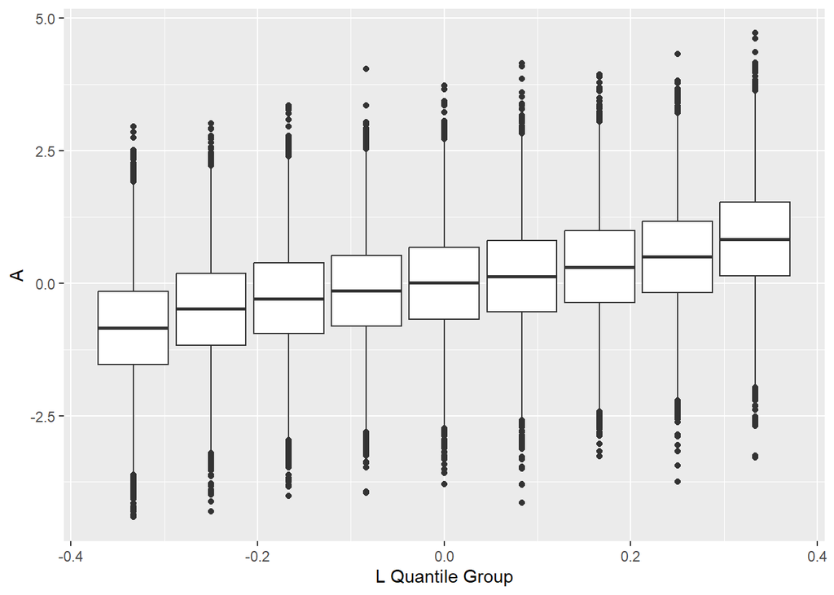

```r
# plot observed A by L quantile
dat1 %>%
  mutate(L.grp = ntile(L, 9)) %>%
  ggplot(aes(y = A, group = L.grp)) +
  geom_boxplot() +
  labs(x = "L Quantile Group",
       y = "A")
```

We can fit this using the g-formula by fitting a model for $Y|A,L$ then marginalizing over $L$. This gives essentially the correct MSM parameters.

```r
# Fit using g-formula -----------------------------------------------------
args <- list(formula = "~A + L",
             inv.link = inv.ident,
             d.inv.link = d.inv.ident)

res.G1 <- fit.gfmla(
  data = dat1,
  a = c(0, 1),
  args = args, return.var = F, return.bcvar = F
)

res.G1$est
```

```
##           g.0           g.1           g.2         EYa.1         EYa.2
## -4.156456e-05  1.000687e+00 -9.966348e-01  2.194967e-03  1.002882e+00
```

```r
EYa <- unname(res.G1$est[4:6])
c(intercept = EYa[1],
  slope = EYa[2] - EYa[1])
```

```
##   intercept       slope
## 0.002194967 1.000686894
```

We can also fit using IPW, by fitting a model for $Y|A$ with weights $SW=f_A(A)/f_{A|L}(A|L)$. This results in MSM parameters that are close to correct.

```r
wts.num <- dnorm(A, mean = mean(A), sd = sd(A))
wts.denom <- dnorm(A, mean = A_mean, sd = 1)
wts <- wts.num / wts.denom

res.I1 <- lm(Y ~ A,
             dat1,
             weights = wts)

res.I1$coefficients
```

```
## (Intercept)           A
## 0.002618383 1.002875725
```